# Ejercicio 2

## David Montero Loaiza

### Problema 1

Consideremos un sistema en el que existe una característica x y una variable dependiente y que se relacionan como y = $a*x$. Supongamos también que para cada valor fijo de x la medida y viene dada por una pdf gaussiana centrada en a * x y con sigma. Escribe una funcion de R que tome como input un vector aleatorio de N elementos de x que tome valores entre [0, 10], el factor a, y sigma; y genere el correspondiente vector y

```r
generate_y = function(x,a,sigma){

  # GAUSSIANA
  y = rnorm(x,x*a,sigma)

  # RETORNAR VECTOR Y
  return(y)

}
```

### Problema 2

Una vez terminada la función genera el vector x con N = 100, y un vector y con a = 2 y sigma = 0.2. Pintalos en una grafica.

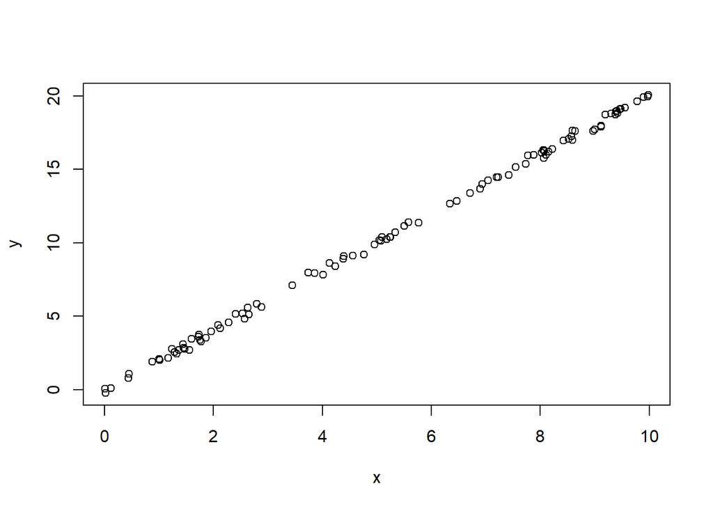

```r
# VECTOR ALEATORIO
N = 100
x = runif(N,0,10)

# PARAMETROS ALPHA Y SIGMA
a = 2
sigma = 0.2

# CREAR VECTOR Y
y = generate_y(x,a,sigma)

# GRAFICA X Y
plot(x,y)
```

### Problema 3

Escribe una función en R a la que le pases un vector y dependiente, un vector x con la caracteristica, y un parametro a y te devuelva el valor de la loss function para ese valor del parámetro a.

```r
loss = function(x,y,a){

  # VALOR DE LA FUNCION DE COSTE
  l = t(y - x * a) %*% (y - x * a)

  # RETORNAR VALOR DE LA FUNCION DE COSTE
  return(l)

}
```

### Problema 4

Llama a la función anterior con diferentes valores del parámetro a, y pinta la curva de la loss function en función de a. Comprueba visualmente que el mínimo está en la posición que nos esperamos.

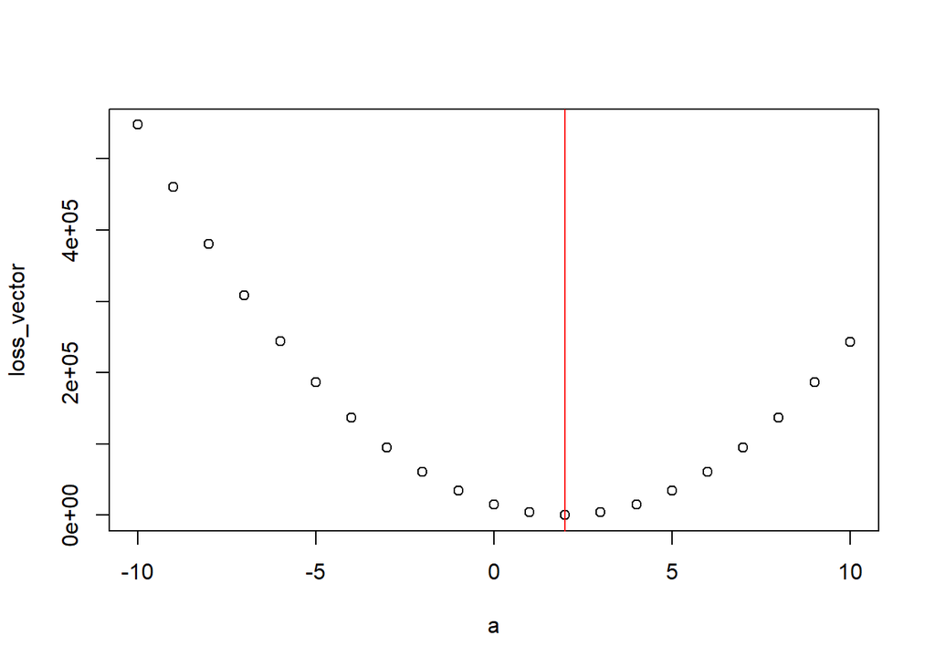

```r
# PRUEBA DE LOSS CON DIFERENTES VALORES DE A
a = -10:10

# CALCULAR VALOR DE LOSS PARA DIFERENTES A
loss_vector = sapply(a,loss,x = x,y = y)

# GRAFICAR EL VALOR DE LOSS EN FUNCION DE A
plot(a,loss_vector)
abline(v = 2,col = "red")
```

La línea roja representa el valor del parámetro a con el cual se genero el vector y, se comprueba visualmente que el mínimo de la función de loss está en ese parámetro.